# COMP24112 - Exercise 3: *Face Recognition* (25 Marks)

## 1. Task description

You will work on the face recognition and face completion tasks. The provided dataset includes face images of 40 subjects. There are a total of 400 images, with 10 images per subject. Each image contains 32×32=1024 pixels, with 256 grey levels per pixel.

You will be marked for your code presentation, design, results, and report. Please note this notebook should take no more than 10 minutes to run on lab computers.

## 2. Preparation

### 2.1 Setting up

The functions that you need are defined in the source file we have provided you with. To use them you must import it first:

```python
from lab3lib import load_data, show_single_face, show_faces, partition_data, split_left_right, join_left_right, show_split_faces
import numpy as np
import matplotlib.pyplot as plt
```

Now you can load the data:

```python
data, labels = load_data()
```

### 2.2 Visualising the dataset

You can observe the faces stored in a data matrix by using the functions `show_single_face()` and `show_faces()`.

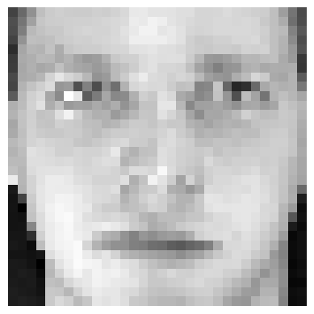

```python
# Display a single example.
show_single_face(data[0, :])
```

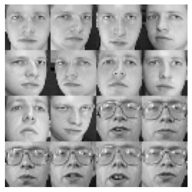

```python
# Display the first 16 examples in a 4x4 grid.
show_faces(data[:16, :], num_per_row=4)
```

### 2.3 Splitting into the train and test sets

First, normalize your pixel values by 1/255 so that the feature values used in later experiments are between $[0,1]$. In general, the normalization trick can make it easier for your to tune parameters in machine learning experiments.

A data partition function is supplied to facilitate your experiments. It randomly splits the provided data into the training and test sets, where the training set contains $N$ samples per class and the test set contains the remaining samples. The function takes the labels and the specified number $N$ as the input. And returns the sample indices in the training and test set. For example, the following code divides a given set of 400 samples into a training set containing 3 samples per subject and a test set containing 7 samples per subject:

```python
# normalization
data = data / 255

# partition
tr_ind, te_ind = partition_data(labels, num_per_class=3)
tr_data = data[tr_ind, :]
tr_label = labels[tr_ind]
te_data = data[te_ind, :]
te_label = labels[te_ind]
```

## 3. $L_2$-regularised least squares (5 marks, Normal)

### 3.1 Implementation

Now, you need to implement the function `l2_rls_train` below.

`l2_rls_train` trains a linear model by minimising the $L_2$-regularised sum of squares loss through zeroing the loss gradient. It should support both single-output and multi-output cases. This function should take a set of training samples and a user-specified regularisation parameter $\lambda$ (lambda) as the input, and return the predicted weights. When $\lambda=0$, use a pseudo-inverse to implement the solution.

```python
def l2_rls_train(data, labels,
                 lmbd): # Add any other arguments here
    """
    Trains model to find weights used for prediting labels of unseen samples.

    data: data  matrix of images for training
    labels: labels matrix for each data sample
    lmbd: regularized parameter

    Returns: weights matrix used for predicting
    """
    n_samples, n_features = data.shape
    # This is just to be consistent with the lecture notes.
    X, y = data, labels

    # Expand X with a column of ones.
    X_tilde = np.hstack((np.ones((len(X), 1)),X))

    # Compute the coefficient vector.
    if lmbd == 0:
        w = np.linalg.pinv(X_tilde) @ y
    else:
        #TODO put notes formula to explain
        w = np.linalg.inv(X_tilde.T @ X_tilde + lmbd * np.eye(n_features + 1)) @ X_tilde.T @ y

    # Return model parameters.
    return w
```

Now, implement the function `l2_rls_predict` below. It should take the trained weights and your query data as the input, and return the corresponding prediction.

```python
def l2_rls_predict(w, data):
    """
    Predcits labels of given data samples.

    data: data matrix to predict labels
    w: weights used for predciting labels

    Returns: the predicted labels
    """

   # Compute the prediction.
    X_tilde = np.hstack((np.ones((data.shape[0], 1)), data))
    predicted_y = X_tilde @ w

    return predicted_y
```

### 3.2 Report

Explain briefly the knowledge supporting your implementation and your design step by step. Explicitly comment on the role of any arguments you have added to your functions.

## 4. Face Recognition (4 Marks, Normal)

### 4.1 Implementation and experiment design

Use your implemented functions to perform multi-class classification to identify the subject in each image, for all 40 subjects.

Split your data to two sets: the training set contains 5 randomly selected images per subject and the test set contains the remaining images. The training set is used to train the model and select hyper-parameter $\lambda$, while the test set is only for final assessment of the trained classifier with the selected $\lambda$.

Design an appropriate and complete machine learning experiment, which should include the training, hyper-parameter selection and evaluation stages. You can choose from the random subsampling, $k$-fold CV and LOO approaches for hyper-parameter selection. In the evaluation, you should construct a $40\times 40$ classification error matrix (confusion matrix) for test samples.

Write your code below and make sure it compiles.

```python
# Your code goes here
# Note that you may find it helpful to use one-hot encoding to deal with multi-class labels
from sklearn.preprocessing import LabelBinarizer
import math


def loo_cv(X, y, lmbd):
    """
    Performs leave-one-out cross-validation with linear regression.

    X: trainng data marix
    y: training labels matrix
    lmbd: regularized parameter

    Returns: accuracy of prediction
    """
    n = X.shape[0]
    confusionMatrix = np.zeros([40, 40])
    predicted = []
    for i in range(n):
        # Remove the i-th sample from the data and labels which will be used for testing
        X_train = np.delete(X, i, axis=0)
        y_train = np.delete(y, i, axis =0)

        # Train the model to get weights/coefficients
        w = l2_rls_train(X_train, y_train, lmbd)

        # Predict the label for the i-th sample
        x_test = X[i].reshape(1, -1)  # Change to (1, n_features)
        y_pred = l2_rls_predict(w, x_test)

        # Change to probability of being a label
        tempProbs = (np.exp(y_pred)/ np.sum(np.exp(y_pred)))
        # Get the most likely predicted label
        predicted.append(np.argmax(tempProbs))


    # One-hot-encoding for creating confusion matrix
    for x in range(0,len(predicted)):
        confusionMatrix[math.floor(x/5)][predicted[x]] += 1
    # Compute accuracy by summing the diagnoal and dividing it by the entire sum of the matrix
    accuracy = np.sum(np.diag(confusionMatrix)) / np.sum(confusionMatrix)

    return accuracy




# partition
tr_ind, te_ind = partition_data(labels, num_per_class=5)
tr_data = data[tr_ind, :]
tr_label = labels[tr_ind]
te_data = data[te_ind, :]
te_label = labels[te_ind]

# Re-make label matricies for one-hot
lb = LabelBinarizer()
tr_label_hot = lb.fit_transform(tr_label)
te_label_hot = lb.transform(te_label)

# lmbd values to experiment on
lmbd_values = [0.001, 0.01, 0.1, 1, 10, 100, 1000]
output = []

# Check accuracy for each lmbd value
for lmbd in lmbd_values:
    acc = loo_cv(tr_data, tr_label_hot, lmbd)
    output.append((acc, lmbd))


for i in range (len(lmbd_values)):
    print(f"when lambda is {output[i][1]}, the accuracy = {output[i][0]}")

# Get the lmbd value which gives most accurate results
sorted_array = sorted(output, key=lambda x: x[0], reverse=True)
best_lmbd_val = sorted_array[0]

print(f"Best lmbd value: {best_lmbd_val[1]}")
```

```
when lambda is 0.001, the accuracy = 0.865
when lambda is 0.01, the accuracy = 0.87
when lambda is 0.1, the accuracy = 0.875
when lambda is 1, the accuracy = 0.885
when lambda is 10, the accuracy = 0.865
when lambda is 100, the accuracy = 0.765
when lambda is 1000, the accuracy = 0.365
Best lmbd value: 1
```

Pick some subjects that are considered the easist to recognise by your classifier, and print the test images from these subjects below.

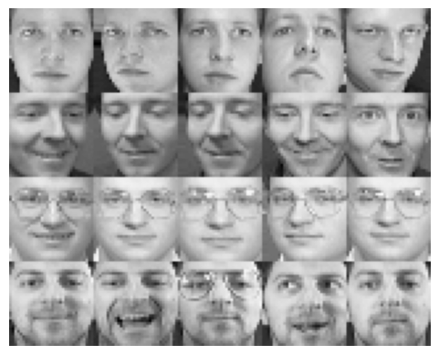

```python
# Your code goes here
acc = []

# Re-train model with best lmbd value and predict using test data
w = l2_rls_train(tr_data, tr_label_hot, best_lmbd_val[1])
y_pred = l2_rls_predict(w, te_data)
# Use softmax to get best predicted label
exp_pred = np.exp(y_pred)
smax = exp_pred/np.sum(exp_pred)

labelsList = []
for val in smax:
    labelsList.append(np.argmax(val))

# Make a confusion matrix for accuracy testing
conf_mat = np.zeros((40,40))

for i in range(0, len(labelsList)):
    labelsList[i] += 1
    conf_mat[labelsList[i]-1][te_label[i]-1]+=1


# Calculate accuracy per sample
for i in range(0,40):
    acc.append(conf_mat[i][i]/np.sum(conf_mat[i]))

# Get most accurate labels
best_acc = np.amax(acc)
best_lb = []
for i in range(40):
    if acc[i] == best_acc:
        best_lb.append(i)

# Given most accurate images...
#...the best images are the ones where the acctual label macthes predicted and is also considered best label
goodImages = []
for i in range(200):
    if labelsList[i] == te_label[i] and labelsList[i]in best_lb:
        # Well predicted images are stored in goodImages list
        goodImages.append(te_data[i:i+1])

# Show the top 20 best predicted images
goodImages = np.concatenate(goodImages)
show_faces(goodImages[0:20], num_per_row=5)
```

Pick some subjects that are considered the most difficult to recognise by your classifier, and print the misclassified test images from these subjects below.

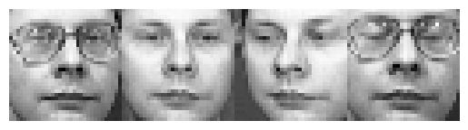

```python
# Your code goes here
acc = []
for i in range(0,40):
    acc.append(conf_mat[i][i]/np.sum(conf_mat[i]))

# Instead of getting most accuratly preicted, get the worst predicted labels
worst_acc = np.amin(acc)
best_lb = []
for i in range(40):
    if acc[i] == worst_acc:
        best_lb.append(i)

badImages = []
for i in range(200):
    if labelsList[i] == te_label[i] and labelsList[i]in best_lb:
        badImages.append(te_data[i:i+1])
badImages = np.concatenate(badImages)

# Show worst predicted faces
show_faces(badImages, num_per_row=4)
```

### 4.2 Report

Explain the classification steps, and report your chosen hyper-parameter and results on the test set. Did you notice any common features among the easiest and most difficult subjects to classify? Describe your observations and analyse your results.

## 5. Face Completion (4 Marks, Normal)

In this task you will predict the 512 pixels of the right face from the 512 pixels of the left face by formulating a regression task.

The following command can be used to extract the left and right faces from the input data.

```python
left, right = split_left_right(data)
```

And you can visualise them with the function `show_split_faces()`:

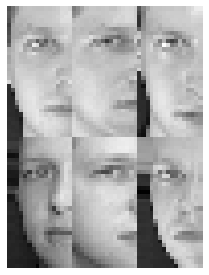

```python
show_split_faces(left[:6, :], num_per_row=3)
```

### 5.1 Implementation and experiment design

Build a face completion model using your regularised least squares model. Design an experiment to assess your model, which should include appropriate training and testing. Use mean absolute percentage error (MAPE) to evaluate the regression performance. You do not need to bother with hyper-parameter selection, but simply set $\lambda$=0.

Write your code below and make sure it compiles.

```python
# Your code goes here
# Partition data
tr_ind, te_ind = partition_data(labels, num_per_class=3)
tr_data = data[tr_ind, :]
tr_label = labels[tr_ind]
te_data = data[te_ind, :]
te_label = labels[te_ind]

# Split data into left side faces for training/testing data...
# ... and right side for training/testing labels
left_train, right_train = split_left_right(tr_data)
left_test, right_test = split_left_right(te_data)

# Get weights using left side training faces as data and right side training face as the label
model_w = l2_rls_train(left_train, right_train, 0)
# Get predictions using left side testing faces as data
prediction = l2_rls_predict(model_w, left_test)
# Compute mean absolute percentage accuracy
mape = np.mean(np.abs((right_test - prediction)/right_test)*100)
print(mape)
```

```
20.698904217567378
```

Visualise and compare the ground truth face (include both the left and right parts) and the completed face (include both the true left and predicted right parts) for 3 randomly chosen testing samples below. You can use `join_left_right(left, right)` to concatenate the left and right halves of a set of faces.

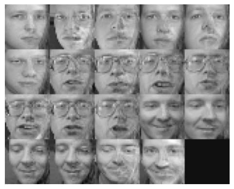

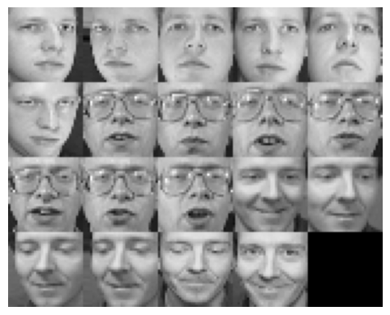

```python
# Your code goes here
# Join left side acctual face with right side predicted face
joint_faces = join_left_right(left_test, prediction)
# Join left side acctual face with right side acctual face for comparison
joint_faces_og = join_left_right(left_test, right_test)
# Show the faces
show_faces(joint_faces[1:20], num_per_row=5)
show_faces(joint_faces_og[1:20], num_per_row=5)
```

### 5.2 Report

Report the MAPE and make some observations regarding the results of the face completion model. How well has your model performed? Offer one suggestion for how it can be improved.

## 6. Training linear least squares model via gradient descent (5 marks, Normal)

For these experiments you will be performing **binary classification.**

### 6.1 GD Implementation

Now, implement the function `lls_gd_train` below.

`lls_gd_train` trains a single-output linear model by minimising the sum of squares loss using the gradient descent approach. It should take the iteration number $N$ and the learning rate $\eta$ as the input. To keep things simple, you can fix the initial guess of the model weights $\mathbf{w}$ as zeros. It should record and return the weights and costs of linear least squares model calculated in all the iterations.

```python
def lls_gd_train(data, labels, N, learning_rate# Add any other arguments here if needed
          ):
    """
    LLS model for training using gradient descent approach to minimise sum of squares loss.

    data: data  matrix of images for training
    labels: labels matrix for each data sample
    N: number of iterations
    learning_rate: learning rate for model to use

    Returns: the costs per iteration (cost_all) and weights for predicting labels of unseen data (w_all)
    """

    # This is just to be consistent with the lecture notes.
    X, y = data, labels

    # Expand X with a column of ones.
    # A matrix where the first column is all ones and the remaining columns are the original features of data
    X_tilde = np.hstack((np.ones((len(data), 1), dtype=int), data))
    #X_tilde = np.hstack((np.ones((len(X), 1)),X)) # MINE

    # Weight initialization
    #  weights where the first element corresponds to the bias term and the remaining elements correspond to the weights associated with each feature
    w = np.zeros(X_tilde.shape[1])

    # Initialise arrays to store weights and cost at each iteration
    w_all = []
    cost_all = []


    # GD update of weights
    for i in range(N):

        # Cost and gradient descent of the linear least squares model
        # Using formula from lecture notes to calculate gradient and cost
        gd = X_tilde.T @ X_tilde @ w - X_tilde.T @ y
        cost = 0.5 * np.sum((w @ X_tilde.T - y)**(2))

        # Weight update
        w = w - learning_rate * gd

        # save w and cost of each iteration in w_all and cost_all
        w_all.append(w)
        cost_all.append(cost)


    # Return model parameters.
    return cost_all, w_all
```

### 6.2 Experiments

Apply this function to classify images from subject 1 and subject 30. You only need to conduct the experiment for one training-test trial, where 3 images from each subject are used for training and the remaining 7 images for testing.

Set your learning rate small, e.g., $\eta=10^{-3}$, and use a reasonable iteration number, e.g., $N=200$, to train your model. Plot in three figures (1) the change of your sum-of-squares error loss that you minimise, (2) the change of the classification accuracy for training samples, and (3) the change of the classification accuracy for test samples over iterations. Write your code below and make sure it runs.

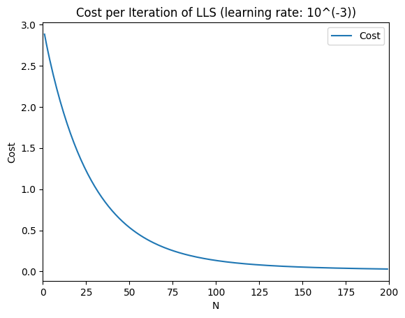

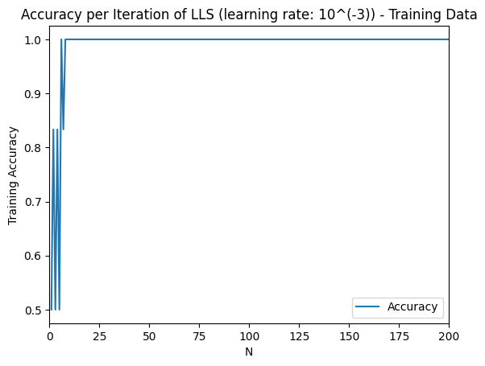

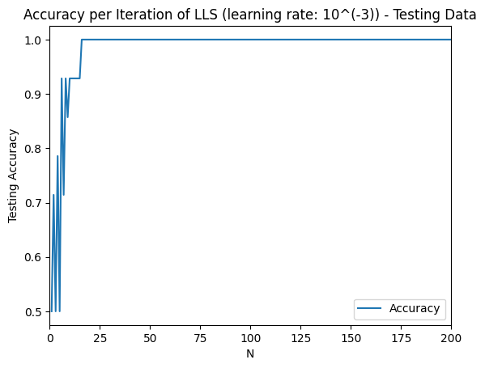

```python
# Your code goes here
import matplotlib.pyplot as plt

# Only get data from labels 1 and 30
subject_mask = np.logical_or(labels == 1, labels == 30)
data = data[subject_mask]
labels = labels[subject_mask]

# Partition data, 3 samples for training and 7 for testing
tr_ind, te_ind = partition_data(labels, num_per_class=3)
tr_data = data[tr_ind, :]

# Make labels as 1 for person 1 and -1 for person 2
# Stay consistent with lecture notes
tr_label = np.array([1,1,1,-1,-1,-1])
te_data = data[te_ind, :]
te_label = np.array([1,1,1,1,1,1,1,-1,-1,-1,-1,-1,-1,-1])

# Train model using 10^(-3) as learning rate
cost_all_LLS, w_all = lls_gd_train(tr_data, tr_label, 200, 10**-3)

# COSTS
num_iterations = len(cost_all_LLS)-1
fig, ax = plt.subplots()
ax.set_title('Cost per Iteration of LLS (learning rate: 10^(-3))')
# Plot the costs vs iteration number
ax.plot(range(1, num_iterations + 1), cost_all_LLS[1:], label='Cost')
ax.set_xlabel('N')
ax.set_ylabel('Cost')
ax.set_xlim(0, 200)
ax.legend()
# Display graph
plt.show()



# TRAINING ACCURACY
meanTraining = []
count1 = 0
for w in w_all:
    # Predict training data labels agasint each w
    predicted_training = l2_rls_predict(w, tr_data)
    # Where value is greater than or equal to 0, change to label 1...
    # ... otherwise change value to label -1
    updated_training_labels = np.where(np.array(predicted_training) >= 0, 1, -1)
    total = 0
    # Count all correctly predicted matches
    for i in range(len(updated_training_labels)):
        if updated_training_labels[i] == tr_label[i]:
            total += 1
    # Compute accuracy
    meanTraining.append(total/ len(updated_training_labels))

num_iterations1 = len(meanTraining)
fig1, ax1 = plt.subplots()
ax1.set_title('Accuracy per Iteration of LLS (learning rate: 10^(-3)) - Training Data')
# Plot the accuracy vs iteration number for training data
ax1.plot(range(1, num_iterations1 + 1), meanTraining, label='Accuracy')
ax1.set_xlabel('N')
ax1.set_ylabel('Training Accuracy')
ax1.set_xlim(0, 200)
ax1.legend()
# Display graph
plt.show()



# TEST ACCURACY
meanTest_LLS = []
for w in w_all:
    # Predict testing data labels agasint each w
    predicted_testing = l2_rls_predict(w, te_data)
    # Where value is greater than or equal to 0, change to label 1...
    # ... otherwise change value to label -1
    updated_testing_labels = np.where(np.array(predicted_testing) >= 0, 1, -1)
    total = 0
    # Count all correctly predicted matches
    for i in range(len(updated_testing_labels)):
        if updated_testing_labels[i] == te_label[i]:
            total += 1
    # Compute accuracy
    meanTest_LLS.append(total/ len(updated_testing_labels))


num_iterations2 = len(meanTest_LLS)
fig2, ax2 = plt.subplots()
ax2.set_title('Accuracy per Iteration of LLS (learning rate: 10^(-3)) - Testing Data')
# Plot the accuracy vs iteration number for testing data
ax2.plot(range(1, num_iterations2 + 1), meanTest_LLS, label='Accuracy')
ax2.set_xlabel('N')
ax2.set_ylabel('Testing Accuracy')
ax2.set_xlim(0, 200)
ax2.legend()
# Display graph
plt.show()
```

Try a larger learning rate, e.g., $\eta=10^{-2}$, and produce the same three plots by training the model for $N=200$ iterations. Write your code below and make sure it runs.

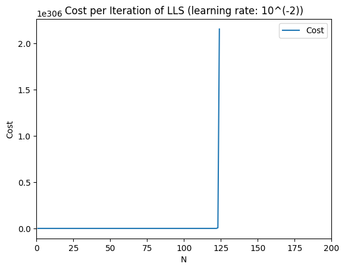

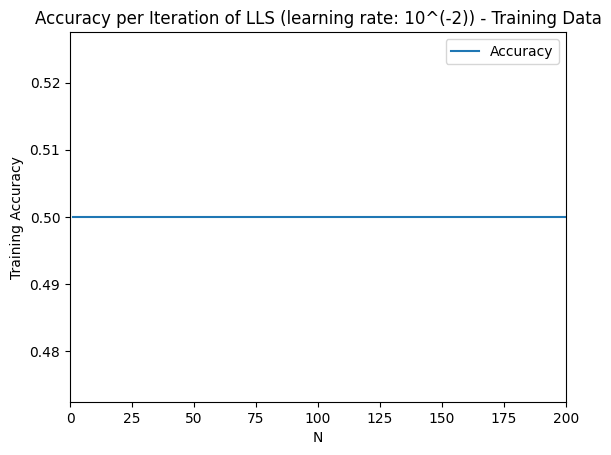

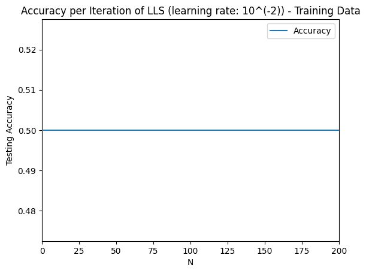

```python
# Your code goes here
import matplotlib.pyplot as plt

# Only get data from labels 1 and 30
subject_mask = np.logical_or(labels == 1, labels == 30)
data = data[subject_mask]
labels = labels[subject_mask]
# Partition data, 3 samples for training and 7 for testing
tr_ind, te_ind = partition_data(labels, num_per_class=3)
tr_data = data[tr_ind, :]

# Make labels as 1 for person 1 and -1 for person 2
# Stay consistent with lecture notes
tr_label = np.array([1,1,1,-1,-1,-1])
te_data = data[te_ind, :]
te_label = np.array([1,1,1,1,1,1,1,-1,-1,-1,-1,-1,-1,-1])

# Train model using 10^(-2) as learning rate
cost_all, w_all = lls_gd_train(tr_data, tr_label, 200, 10**-2)

# COSTS
num_iterations = len(cost_all)-1
fig, ax = plt.subplots()
ax.set_title('Cost per Iteration of LLS (learning rate: 10^(-2))')
# Plot the costs vs iteration number
ax.plot(range(1, num_iterations + 1), cost_all[1:], label='Cost')
ax.set_xlabel('N')
ax.set_ylabel('Cost')
ax.set_xlim(0, 200)
ax.legend()
# Display graph
plt.show()


# TRAINING ACCURACY
meanTraining = []
count1 = 0
for w in w_all:
    # Predict training data labels agasint each w
    predicted_training = l2_rls_predict(w, tr_data)
    # Where value is greater than or equal to 0, change to label 1...
    # ... otherwise change value to label -1
    updated_training_labels = np.where(np.array(predicted_training) >= 0, 1, -1)
    total = 0
    # Count all correctly predicted matches
    for i in range(len(updated_training_labels)):
        if updated_training_labels[i] == tr_label[i]:
            total += 1
    # Compute accuracy
    meanTraining.append(total/ len(updated_training_labels))


num_iterations1 = len(meanTraining)
fig1, ax1 = plt.subplots()
ax1.set_title('Accuracy per Iteration of LLS (learning rate: 10^(-2)) - Training Data')
# Plot the accuracy vs iteration number for training data
ax1.plot(range(1, num_iterations1 + 1), meanTraining, label='Accuracy')
ax1.set_xlabel('N')
ax1.set_ylabel('Training Accuracy')
ax1.set_xlim(0, 200)
ax1.legend()
# Display graph
plt.show()



# TEST ACCURACY
meanTest = []
for w in w_all:
    # Predict testing data labels agasint each w
    predicted_testing = l2_rls_predict(w, te_data)
    # Where value is greater than or equal to 0, change to label 1...
    # ... otherwise change value to label -1
    updated_testing_labels = np.where(np.array(predicted_testing) >= 0, 1, -1)
    total = 0
    # Count all correctly predicted matches
    for i in range(len(updated_testing_labels)):
        if updated_testing_labels[i] == te_label[i]:
            total += 1
    # Compute accuracy
    meanTest.append(total/ len(updated_testing_labels))


num_iterations2 = len(meanTest)
fig2, ax2 = plt.subplots()
ax2.set_title('Accuracy per Iteration of LLS (learning rate: 10^(-2)) - Training Data')
# Plot the accuracy vs iteration number for testing data
ax2.plot(range(1, num_iterations2 + 1), meanTest, label='Accuracy')
ax2.set_xlabel('N')
ax2.set_ylabel('Testing Accuracy')
ax2.set_xlim(0, 200)
ax2.legend()
# Display graph
plt.show()
```

### 6.3 Report

How did you choose the learning rate and iteration number? Explain your results.

## 7. Advanced Gradient-based Training

For this section, you may choose to implement **either Option 1: SGD** (4 marks), or **Option 2: GD with hinge loss** (7 marks).

*Please note: Option 1 is easier, but gives fewer potential marks. Option 2 is designed to be a steep challenge, potentially involves mathematical derivations not shown in your notes, and will be marked rigorously. Choose wisely!*

### Option 1: Compare with stochastic gradient descent training (4 marks, Normal)

### 7.1 SGD Implementation

Replace the gradient descent approach that you did in Section 4 with a stochastic gradient descent approach. Your new implementation can be named as `lls_sgd_train`. You can adopt a similar implementation template to that of your `lls_gd_train` function.

```python
# Your code goes here
```

### 7.2 Experiment Design

Design and implement an appropriate experiment to demonstrate the performance and behaviour difference between gradient descent and stochastic gradient descent.

```python
# Your code goes here
```

### 7.3 Report

Explain in the report your experiment design, comparative result analysis and interpretation of obtained results. Try to be thorough in your analysis.

**Remember that all graphs should have axis labels and a title.**

### Option 2: Gradient descent training using hinge loss (7 marks, Hard)

Here is a recap of Hinge loss. For a single output model, the hinge loss over N training samples is $$O(\theta) = \sum^N_{i=1}\max\left(0, 1 - y_i f(\theta, x_i)\right)$$ where $y_i \in \{-1, +1\}$ is the class target label and $f(\theta, x_i)$ is your prediction function. While this is not directly differentiable, we can split it into two separately differentiable parts. For one sample, the above formuation is equivalent to: $$ \max\left(0, 1 - y_i f(\theta, x_i)\right) = \begin{cases} 0 & \text{if } y_i f(\theta, x_i) \geq 1 \\ % & is your "\tab"-like command (it's a tab alignment character) 1-y_i f(\theta, x_i) & \text{otherwise.} \end{cases} $$

### 7.1 Implementation

Apply the gradient descent approach to train your classifier but by minimising the hinge loss. Implement the function `hinge_gd_train` below.

`hinge_gd_train` trains a single-output linear model by minimising the hinge loss using the gradient descent approach. The optimisation function should include a regularisation term and regularisation hyperparameter $C$. It should take the iteration number $N$, the learning rate $\eta$, and regularisation hyperparameter $C$ as arguments. To keep things simple, you can fix the initial guess of the model weights $\mathbf{w}$ as zeros. It should record and return the weights and costs of the regularised hinge loss model calculated in all the iterations.

```python
def calculate_gradient(X_tilde, y, w, C):
    # Calculate the value of the margin function for each sample
    v = y * (X_tilde @ w)
    # Create a matrix of gradients for each sample with a margin less than 1
    grad_mat = [y[i] * X_tilde[i] for i in range(len(v)) if v[i] < 1]
    # Calculate the final gradient as the sum of the gradients multiplied by the regularization parameter C
    grad = -C * np.sum(grad_mat, axis=0)
    return grad

def hinge_gd_train(data, labels, learning_rate, N, C# Add any other arguments here if needed
          ):
    """
    Training model for minimising hinge loss using gradient descent approach.
    data: data  matrix of images for training
    labels: labels matrix for each data sample
    learning_rate: learning rate for model to use
    N: number of iterations
    C: regularization hyperparameter

    Returns: the costs per iteration (cost_all) and weights for predicting labels of unseen data (w_all)
    """
    # This is just to be consistent with the lecture notes.
    X, y = data, labels
    # Expand X with a column of ones.
    X_tilde = np.hstack((np.ones((X.shape[0], 1)), X))

    # Initialise arrays to store weights and cost at each iteration
    w = np.zeros(X_tilde.shape[1])
    w_all = []
    cost_all = []

    # Your code goes here

    # GD update of weights
    for i in range(N):
        # cost and gradient descent of the linear hinge loss model
        # Following lecture notes to compute cost getting the maximum of 0 or 1-yf((X_tilde.w)))
        # As well as multiplying the sum by the hyper-parameter and adding regularised the regularised term
        cost = C * np.sum(np.maximum(0, 1 - y * ((X_tilde @ w)))) + 0.5 * w.T @ w
        # Calculate gradient
        grad = calculate_gradient(X_tilde, y, w, C)

        # save w and cost of each iteration in w_all and cost_all
        w = w - learning_rate * grad
        cost_all.append(cost)
        w_all.append(w)


    # Return model parameters.
    return cost_all, w_all
```

### 7.2 Experiment design

Design and implement an appropriate experiment to demonstrate the performance and behaviour difference for gradient descent training based on the least squared loss and the hinge loss.

```python
# Your code goes here
# Only get data from labels 1 and 30
subject_mask = np.logical_or(labels == 1, labels == 30)
data = data[subject_mask]
labels = labels[subject_mask]
# Partition data, 3 samples for training and 7 for testing
tr_ind, te_ind = partition_data(labels, num_per_class=3)
tr_data = data[tr_ind, :]

# Make labels as 1 for person 1 and -1 for person 2
# Stay consistent with lecture notes
tr_label = np.array([1,1,1,-1,-1,-1])
te_data = data[te_ind, :]
te_label = np.array([1,1,1,1,1,1,1,-1,-1,-1,-1,-1,-1,-1])

# Testing against the following regularization terms to find optimal
regularization_param = [1e-4,1e-3,1e-2,1e-1,1,10,100,1000]

ACC = []

for rp in regularization_param:
    # Train model for each regularization term
    costs, ws  = hinge_gd_train(tr_data, tr_label, 1e-3, 200, rp)
    meanTest = []
    for w in ws:
        # Predict testing data labels agasint each w
        predicted_testing = l2_rls_predict(w, te_data)
        # Where value is greater than or equal to 0, change to label 1...
        # ... otherwise change value to label -1
        updated_testing_labels = np.where(np.array(predicted_testing) >= 0, 1, -1)
        total = 0
        # Count all correctly predicted matches
        for i in range(len(updated_testing_labels)):
            if updated_testing_labels[i] == te_label[i]:
                total += 1
        # Compute accuracy
        meanTest.append(total/ len(updated_testing_labels))
    # Store accuracy and reularized paramter which achieved that accuracy in a 2d array
    ACC.append([np.mean(meanTest),rp])

# Find the bst accuracy and the paramter which achieved it
sorted_list_ACC = sorted(ACC, key=lambda x: x[0], reverse=True)
# Store best C value
best_C_val = sorted_list_ACC[0][1]

print(sorted_list_ACC[0])
```

```
[0.9421428571428572, 1]
```

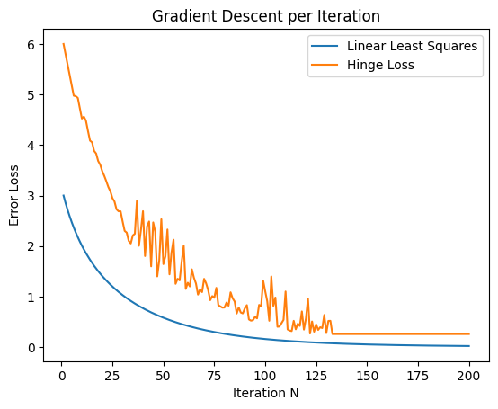

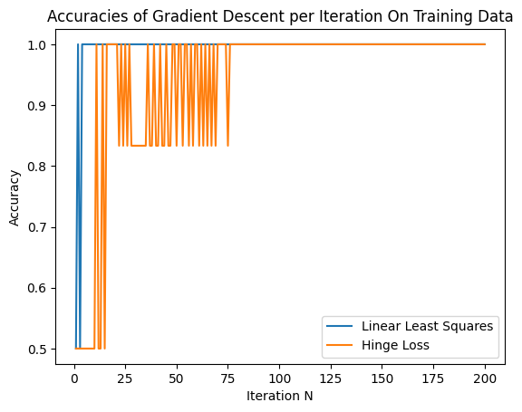

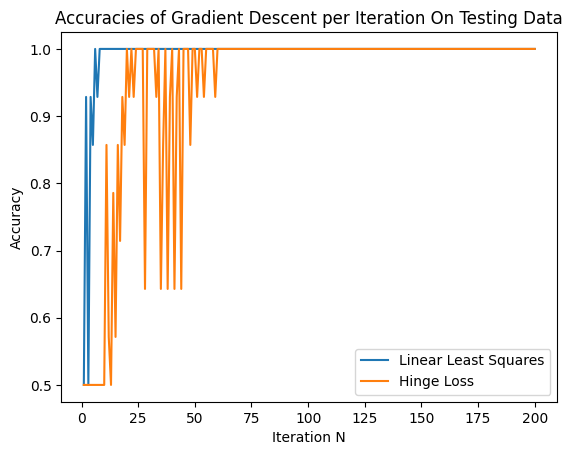

```python
# Only get data from labels 1 and 30
subject_mask = np.logical_or(labels == 1, labels == 30)
data = data[subject_mask]
labels = labels[subject_mask]

# Partition data, 3 samples for training and 7 for testing
tr_ind, te_ind = partition_data(labels, num_per_class=3)
tr_data = data[tr_ind, :]

# Make labels as 1 for person 1 and -1 for person 2
# Stay consistent with lecture notes
tr_label = np.array([1,1,1,-1,-1,-1])
te_data = data[te_ind, :]
te_label = np.array([1,1,1,1,1,1,1,-1,-1,-1,-1,-1,-1,-1])


# Train the hinge loss model using best C value
costs_HL, ws  = hinge_gd_train(tr_data, tr_label, 1e-3, 200, best_C_val)
# Train the LLS model using optimal paramters from previous experiment (6.2)
cost_all_LLS, w_all = lls_gd_train(tr_data, tr_label, 200, 10**-3)



x_axis1 = np.arange(1, len(costs_HL)+1, 1)
plt.figure()
plt.title("Gradient Descent per Iteration")
# Plot the error loss vs iteration number for hinge loss and LLS
plt.plot(x_axis1, cost_all_LLS, label = "Linear Least Squares")
plt.plot(x_axis1, costs_HL, label = "Hinge Loss")
plt.xlabel("Iteration N")
plt.ylabel("Error Loss")
plt.legend()
# Display graph
plt.show()


# TRAIN ACCURACY HL
meanTrain_HL = []
for w in ws:
    # Predict training data labels agasint each w from HL model
    predicted_testing = l2_rls_predict(w, tr_data)
    # Where value is greater than or equal to 0, change to label 1...
    # ... otherwise change value to label -1
    updated_training_labels = np.where(np.array(predicted_testing) >= 0, 1, -1)
    total = 0
    # Count all correctly predicted matches
    for i in range(len(updated_training_labels)):
        if updated_training_labels[i] == tr_label[i]:
            total += 1
    # Compute accuracy
    meanTrain_HL.append(total/ len(updated_training_labels))

# TRAIN ACCURACY LLS
meanTrain_LLS = []
for w in w_all:
    # Predict training data labels agasint each w from LLS model
    predicted_testing = l2_rls_predict(w, tr_data)
    # Where value is greater than or equal to 0, change to label 1...
    # ... otherwise change value to label -1
    updated_training_labels = np.where(np.array(predicted_testing) >= 0, 1, -1)
    total = 0
    # Count all correctly predicted matches
    for i in range(len(updated_training_labels)):
        if updated_training_labels[i] == tr_label[i]:
            total += 1
    # Compute accuracy
    meanTrain_LLS.append(total/ len(updated_training_labels))

x_axis3 = np.arange(1, len(meanTrain_LLS)+1, 1)
plt.figure()
# Plot the Accuracy agasint training data vs iteration number for hinge loss and LLS
plt.title("Accuracies of Gradient Descent per Iteration On Training Data")
plt.plot(x_axis3, meanTrain_LLS, label = "Linear Least Squares")
plt.plot(x_axis3, meanTrain_HL, label = "Hinge Loss")
plt.xlabel("Iteration N")
plt.ylabel("Accuracy")
plt.legend()
# Display graph
plt.show()


# TEST ACCURACY HL
meanTest_HL = []
for w in ws:
    # Predict testing data labels agasint each w from HL model
    predicted_testing = l2_rls_predict(w, te_data)
    # Where value is greater than or equal to 0, change to label 1...
    # ... otherwise change value to label -1
    updated_testing_labels = np.where(np.array(predicted_testing) >= 0, 1, -1)
    total = 0
    # Count all correctly predicted matches
    for i in range(len(updated_testing_labels)):
        if updated_testing_labels[i] == te_label[i]:
            total += 1
     # Compute accuracy
    meanTest_HL.append(total/ len(updated_testing_labels))


# TEST ACCURACY LLS
meanTest_LLS = []
for w in w_all:
    # Predict testing data labels agasint each w from LLS model
    predicted_testing = l2_rls_predict(w, te_data)
    # Where value is greater than or equal to 0, change to label 1...
    # ... otherwise change value to label -1
    updated_testing_labels = np.where(np.array(predicted_testing) >= 0, 1, -1)
    total = 0
    # Count all correctly predicted matches
    for i in range(len(updated_testing_labels)):
        if updated_testing_labels[i] == te_label[i]:
            total += 1
    # Compute accuracy
    meanTest_LLS.append(total/ len(updated_testing_labels))

x_axis3 = np.arange(1, len(meanTest_LLS)+1, 1)
plt.figure()
# Plot the Accuracy agasint testing data vs iteration number for hinge loss and LLS
plt.title("Accuracies of Gradient Descent per Iteration On Testing Data")
plt.plot(x_axis3, meanTest_LLS, label = "Linear Least Squares")
plt.plot(x_axis3, meanTest_HL, label = "Hinge Loss")
plt.xlabel("Iteration N")
plt.ylabel("Accuracy")
plt.legend()
# Display graph
plt.show()
```

### 7.3 Report

Explain in your report the following:

(1) Your implementation of `hinge_gd_train`. If you analytically derived the loss function, please include it here.

(2) Your experiment design, comparative result analysis and interpretation of obtained results.

**Remember that all graphs should have axis labels and a title.**